# Deliverable 2: Cluster Analysis, Factor Analysis, Regression

Reading in the Data from Deliverable 1 Will take a subset of this data which includes country, health expenditure levels in 2018, life expectancy in 2018, and the country’s gini coefficient (measuring inequality in the country, with higher scores meaning higher inequality.)

```r
allData <- read.csv ("https://raw.githubusercontent.com/rhsu4/542_Deliv1/main/allDataWide.csv")

row.names(allData) = NULL

#check data types
str(allData)
```

```
'data.frame':   193 obs. of  9 variables:
 $ Country    : chr  "Afghanistan" "Albania" "Algeria" "Andorra" ...
 $ HE2002     : num  78 314 335 2196 119 ...
 $ HE2010     : num  138 452 648 2771 168 ...
 $ HE2018     : num  186 697 963 3607 165 ...
 $ GiniPercent: num  NA 33.2 27.6 NA 51.3 NA 41.4 34.4 34.4 29.7 ...
 $ GiniYear   : num  NA 2017 2011 NA 2018 ...
 $ LE2002     : chr  "56.784" "74.579" "71.605" ".." ...
 $ LE2010     : chr  "61.028" "76.562" "74.938" ".." ...
 $ LE2018     : chr  "64.486" "78.458" "76.693" ".." ...
```

```r
#Have to make LE2018 numeric
allData$LE2018<-as.numeric(allData$LE2018)
```

```
NAs introduced by coercion
```

```r
str(allData)
```

```
'data.frame':   193 obs. of  9 variables:
 $ Country    : chr  "Afghanistan" "Albania" "Algeria" "Andorra" ...
 $ HE2002     : num  78 314 335 2196 119 ...
 $ HE2010     : num  138 452 648 2771 168 ...
 $ HE2018     : num  186 697 963 3607 165 ...
 $ GiniPercent: num  NA 33.2 27.6 NA 51.3 NA 41.4 34.4 34.4 29.7 ...
 $ GiniYear   : num  NA 2017 2011 NA 2018 ...
 $ LE2002     : chr  "56.784" "74.579" "71.605" ".." ...
 $ LE2010     : chr  "61.028" "76.562" "74.938" ".." ...
 $ LE2018     : num  64.5 78.5 76.7 NA 60.8 ...
```

Preparing Data for clustering

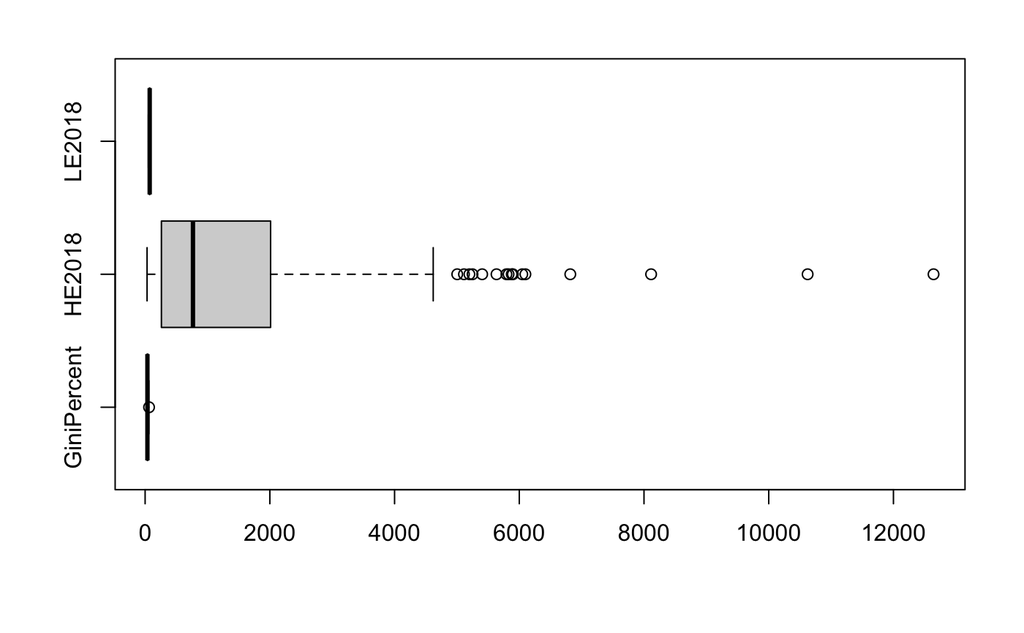

```r
#Setting row names as country names doesn't work because countries are repeating
selection=c("Country", "GiniPercent", "HE2018", "LE2018")
dataToCluster=allData[,selection]

#set labels as row index

row.names(dataToCluster) = dataToCluster$Country
dataToCluster$Country=NULL

#This will give you an error if the country is repeated (because row index names need to be unique)

#Decide if data needs to be transformed
boxplot(dataToCluster, horizontal=T)
```

```r
#Yes, has to be transformed, on different scales
```

Standardizing Data, because on a different scale

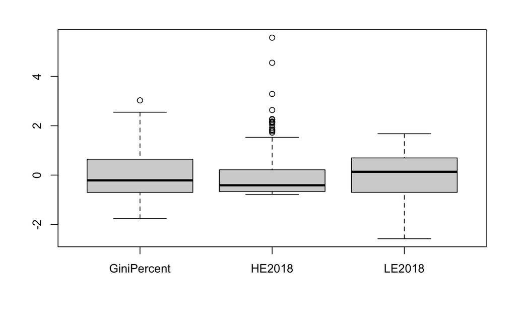

```r
#### standardizing
DataToClusterStd<-as.data.frame(scale(dataToCluster))

### or smoothing
#log(DataToClusterStd)

boxplot(DataToClusterStd)
```

2. Compute the DISTANCE MATRIX

```r
set.seed(999) # this is for replicability of results
```

```r
dtcsFinal <- na.omit(DataToClusterStd)
#This includes only instances that have no missing values (153 obs left)
```

```r
library(cluster)
dtcsFinal_DM = daisy (x=dtcsFinal, metric = "gower")
#This creates the distance metric
```

Compute Clusters - Computer suggestions Using function fviz_nbclust from the library factoextra we can see how many clustered are suggested.

```r
#for partitioning
library(factoextra)
```

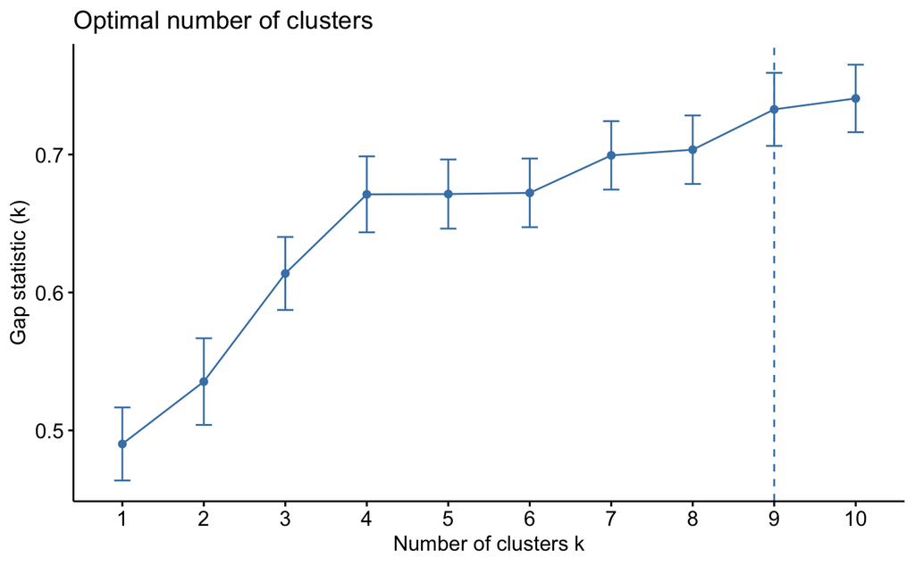

```r
#Missing values - have to either add imputed (mean) values, or remove variables that have missing data
#Here, removing NAs

fviz_nbclust(dtcsFinal,
             pam,
             diss=dtcsFinal_DM,
             method = "gap_stat",
             k.max = 10,verbose = F)
```

```r
#Optimal number of clusters = 9
```

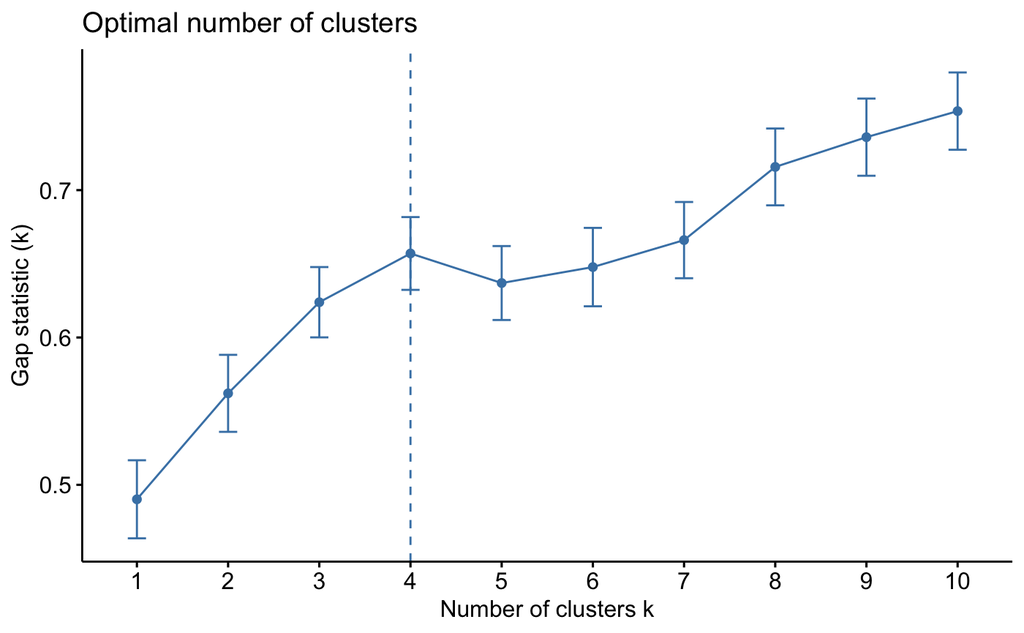

```r
#hierarchical - agglomerative
fviz_nbclust(dtcsFinal,
             hcut,
             diss=dtcsFinal_DM,
             method = "gap_stat",
             k.max = 10,
             verbose = F,
             hc_func = "agnes")
```

```r
#agglomerative optimal # of clusters = 4? 4 is a local average though, so maybe 8 or 9 is better
```

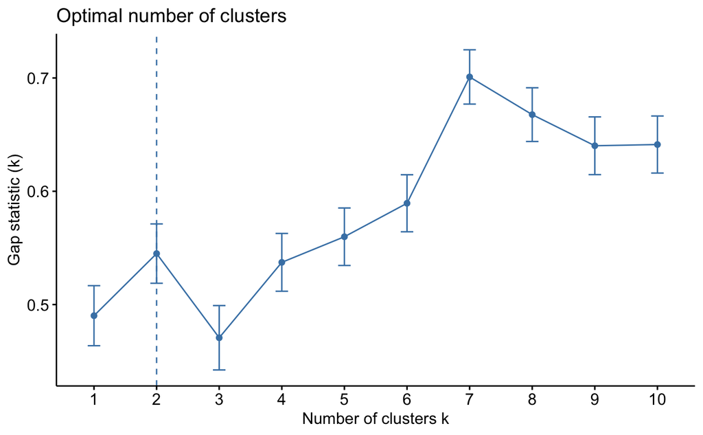

```r
#hierarchical (divisive)
fviz_nbclust(dtcsFinal,
             hcut,
             diss=dtcsFinal_DM,
             method = "gap_stat",
             k.max = 10,
             verbose = F,
             hc_func = "diana")
```

```r
#divisive clusters = 2 with local average. Actual ideal might be 7
```

Apply function a priori clusters: (partitioning? first kind) = 9 agglomerative = 4 (or 8, test both) divisive = 7 (or 2, test both)